# Fourth Week: Hypothesis Testing

TIMSS Analysis

Parand Alizadeh

2018-03-09 02:10:10

# تمرین سری چهارم: چقدر ریاضی بلدیم و چرا؟

لطفا مقاله زیر را مطالعه بفرمایید.

[چرایی رتبه ضعیف ایران در آزمون تیمز](https://goo.gl/gX8DZc)

> با استفاده از داده های ارزیابی تیمز ۲۰۱۵ ادعاهای زیر را مورد ارزیابی قراردهید. برای هر سوال علاوه بر استدلال آماری که در غالب آزمون فرض تعریف می شود از تصویرسازی مناسب باهر دو ابزار ggplot2 و highcharter استفاده نمایید. به دلخواه به هفت گزاره از موارد زیر پاسخ دهید.

۱. میران رضایت معلمان در پیشرفت تحصیلی دانش آموزان موثر است.

با استفاده از سوال btdgtjs که میزان رضایت معلمان را نشان میدهد، مدارس با توجه به میانگین معلمها به سه دسته از نظر رضایت مندی تقسیم میشوند و میزان نمره دانش آموزان آن حساب میشود. با توجه به تست آنوا میانگین این سه دسته مساوی نیست بنابراین این فاکتور در میزان موفقیت دانش آموزان در آزمون ریاضی تاثیر دارد. در نهایت بین دو دسته مینیمم و ماکسیمم تست فرض انجام شد و آن جا هم فرض مساوی بودن میانگین ها رد شد.

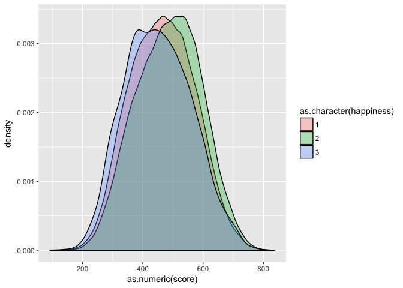

```
##                 Df    Sum Sq Mean Sq F value Pr(>F)
## happiness        1 9.017e+06 9016916   787.9 <2e-16 ***
## Residuals   252607 2.891e+09   11444
## ---
## Signif. codes:  0 '***' 0.001 '**' 0.01 '*' 0.05 '.' 0.1 ' ' 1
```

```
##
##  Welch Two Sample t-test
##
## data:  score by happiness
## t = 13.169, df = 13117, p-value < 2.2e-16
## alternative hypothesis: true difference in means is not equal to 0
## 95 percent confidence interval:
##  12.28787 16.58543
## sample estimates:
## mean in group 1 mean in group 3
##        465.4561        451.0194
```

[interactive chart not shown]

۲. والدینی که تحصیلات بیشتری دارند دارای فرزندان موفق تری می باشند.

با توجه به سوال میزان تحصیلات پدر و مادر در پرسشنامه دانش آموزان، جامعه برحسب مجموع تحصیلات پدر و مادر به ۴ دسته تقسیم شد. طبق تست آنوا برابر بودن میانگین این ۴ دسته رد شد. در نهایت این ۴ دسته به دو دسته بزرگتر تبدیل شدند و تست فرض برابر بودن میانگین این دو دسته را با فرض جایگزین خانواده های با تحصیلات بیشتر فرزندان موفق تری دارند رد میکند.

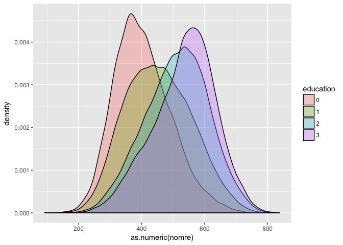

```
##                 Df    Sum Sq   Mean Sq F value Pr(>F)
## edu              1 2.188e+08 218820217   21037 <2e-16 ***
## Residuals   168494 1.753e+09     10402
## ---
## Signif. codes:  0 '***' 0.001 '**' 0.01 '*' 0.05 '.' 0.1 ' ' 1
```

[interactive chart not shown]

```
##
##  Welch Two Sample t-test
##
## data:  dow$nomre and yek$nomre
## t = 146.45, df = 80566, p-value < 2.2e-16
## alternative hypothesis: true difference in means is greater than 0
## 95 percent confidence interval:
##  80.10469      Inf
## sample estimates:
## mean of x mean of y
##  504.9930  423.9784
```

۳. امکانات رفاهی در خانه موجب پیشرفت تحصیلی می گردد.

ابتدا با سوالاتی که درباره امکانات در منزل در پرسشنامه دانش آموز بود امتیازی برای امکانات در نظر گرفته شد. با تست آنوا برابر بودن میانگین این دسته ها رد شد. در نهایت این ۱۲ دسته به ۲ دسته کلی تقسیم شد و طبق تست فرض، برابر بودن میانگین آنها با فرض یک بیشتر بودن میانگین نمرات امکانات بیشتر رد شد.

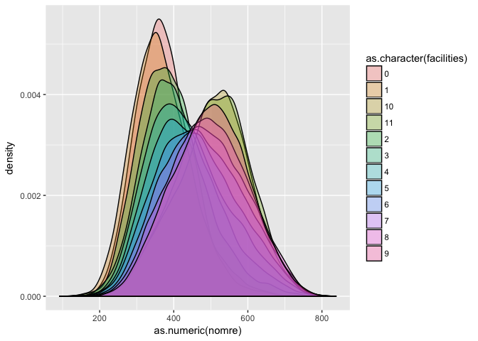

```
##                 Df    Sum Sq   Mean Sq F value Pr(>F)
## facilities       1 1.557e+08 155748343   14158 <2e-16 ***
## Residuals   190656 2.097e+09     11001
## ---
## Signif. codes:  0 '***' 0.001 '**' 0.01 '*' 0.05 '.' 0.1 ' ' 1
```

```
##
##  Welch Two Sample t-test
##
## data:  yek$nomre and dow$nomre
## t = -105.93, df = 35566, p-value < 2.2e-16
## alternative hypothesis: true difference in means is less than 0
## 95 percent confidence interval:
##       -Inf -71.08211
## sample estimates:
## mean of x mean of y
##  413.6640  485.8673
```

[interactive chart not shown]

۴. محیط آرام مدرسه نقش مهمی در پیشرفت تحصیلی دارد.

۵. معلمان با تحصیلات بالاتر یا تجربه بیشتر دانش آموزان موفق تری تربیت می کنند.

ابتدا با توجه به سوال های میزان تحصیلات و تجربه برای معلمان، امتیازی بر اساس این دو معیار برایشان حساب شد. سپس در مدارس میانگین امتیاز معلمان حساب شد و جامعه بر این اساس به چند دسته تقسیم شد. طبق تست آنوا میانگین این دسته ها برابر نیست. در نهایت این دسته ها را به دو دسته کلی تقسیم کردیم و طبق تست فرض، فرض جایگزین بیشتر بودن نمره های دسته با معلمان باتجربه و تحصیل کرده فرض ۰ را رد کرد.

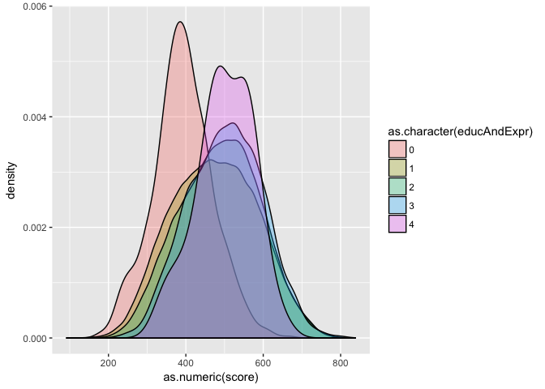

```
##                 Df    Sum Sq  Mean Sq F value Pr(>F)
## educAndExpr      1 1.539e+07 15392091    1357 <2e-16 ***
## Residuals   230096 2.610e+09    11343
## ---
## Signif. codes:  0 '***' 0.001 '**' 0.01 '*' 0.05 '.' 0.1 ' ' 1
```

```
##
##  Welch Two Sample t-test
##
## data:  dow$score and yek$score
## t = 44.365, df = 152270, p-value < 2.2e-16
## alternative hypothesis: true difference in means is greater than 0
## 95 percent confidence interval:
##  20.35636      Inf
## sample estimates:
## mean of x mean of y
##  488.0545  466.9143
```

[interactive chart not shown]

۶. پسران در کاربرد هندسه قوی تر هستند.

با توجه به توزیع تعداد درستی دختران و پسران در سوالات کاربرد هندسه همانطور که در نمودار مشخص است، این دو توزیع تقریبا یکسان هستند. در تست فرض نیز چون مقدار p-value زیاد است نمیتوان فرض ۰ که برابر بودن میانگین است را رد کرد.

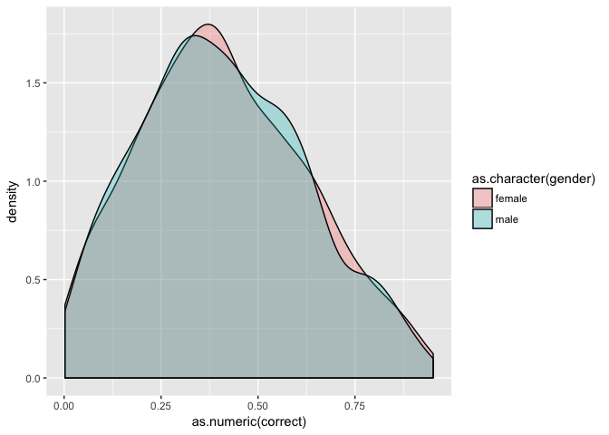

```
##
##  Welch Two Sample t-test
##
## data:  correct by gender
## t = 0.23614, df = 1493.7, p-value = 0.8134
## alternative hypothesis: true difference in means is not equal to 0
## 95 percent confidence interval:
##  -0.01907826  0.02430046
## sample estimates:
## mean in group female   mean in group male
##            0.4112235            0.4086124
```

[interactive chart not shown]

۷. تغذیه دانش آموزان نقش اساسی در یادگیری آنها دارد.

با در نظر گرفتن صبحانه خوردن دانش آموزان و صبحانه و ناهار در مدرسه (و با اولویت دادن به صبحانه خوردن دانش آموزان) امتیازی برای هرکس محاسبه شد. در نهایت طبق این امتیاز جامعه به دو دسته تقسیم شد. طبق تست فرض، فرض بیشتر بودن میانگین کسانی که تغذیه بهتری دارند فرض ۰ را رد کرد.

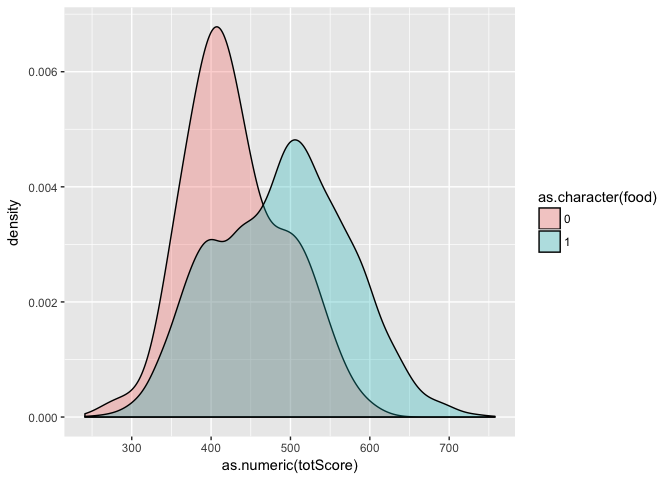

```
##
##  Welch Two Sample t-test
##
## data:  yek$totScore and dow$totScore
## t = -9.5188, df = 113.61, p-value < 2.2e-16
## alternative hypothesis: true difference in means is less than 0
## 95 percent confidence interval:
##      -Inf -48.2551
## sample estimates:
## mean of x mean of y
##  431.1874  489.6233
```

[interactive chart not shown]

۸. مدارس با امکانات بیشتر دارای عملکرد بهتری می باشند.

۹. علت افت تحصیلی عدم مشارکت در کلاس است.

۱۰. دانش آموزان ایرانی در استدلال قوی تر از کاربرد هستند.

با توجه به نموداری که توزیع دو دسته استدلال و کاربرد را در ایران نشان میدهد متوجه میشویم که کاربرد از استدلال میانگین بیشتری دارد که تست فرض هم با این فرض جایگزین فرض ۰ را رد میکند.

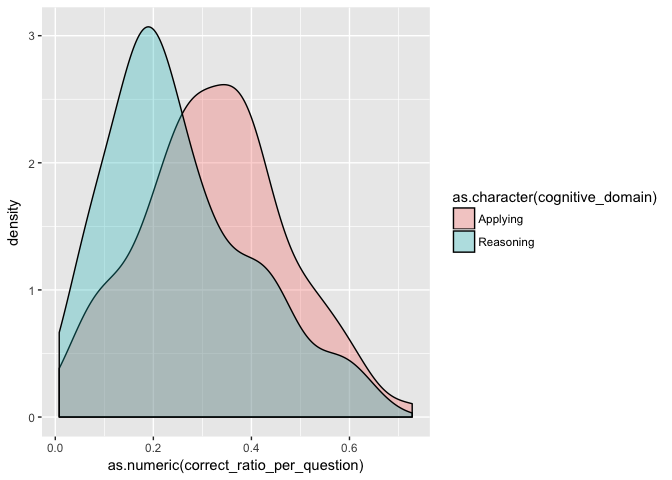

```
##
##  Welch Two Sample t-test
##
## data:  r and ap
## t = -2.6374, df = 90.055, p-value = 0.00492
## alternative hypothesis: true difference in means is less than 0
## 95 percent confidence interval:
##         -Inf -0.02566765
## sample estimates:
## mean of x mean of y
## 0.2540000 0.3233984
```

[interactive chart not shown]

سه گزاره جالب کشف کنید و ادعای خود را ثابت نمایید.

دانش آموزانی که فکر میکنند در ریاضی خوب هستند نمرات بهتری در آن کسب میکنند.

بر اساس سوالاتی که راجع به قوی بودن در ریاضی از دانش آموزان پرسیده شده بود امتیازی برای دانش آموزان محاسبه شد که طبق تست آنوا دسته های متفاوت در این امتیاز میانگین متفاوتی دارند. حال کل جامعه به دو دسته کلی تقسیم میشود. طبق تست فرض، فرض جایگزین دانش آموزان با تصور بهتر میانگین بهتری دارند فرض ۰ را رد میکند.

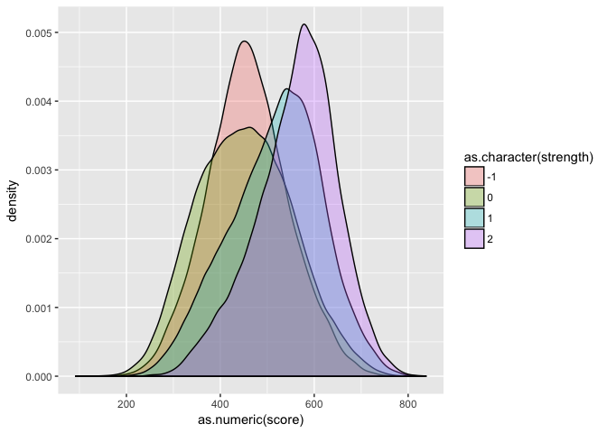

```
##                 Df    Sum Sq   Mean Sq F value Pr(>F)
## strength         1 2.767e+08 276656249   27952 <2e-16 ***
## Residuals   257421 2.548e+09      9898
## ---
## Signif. codes:  0 '***' 0.001 '**' 0.01 '*' 0.05 '.' 0.1 ' ' 1
```

```
##
##  Welch Two Sample t-test
##
## data:  score by totalStrength
## t = -36.883, df = 22538, p-value < 2.2e-16
## alternative hypothesis: true difference in means is less than 0
## 95 percent confidence interval:
##       -Inf -23.82802
## sample estimates:
## mean in group -1  mean in group 0
##         458.9084         483.8487
```

[interactive chart not shown]

میزان تکالیف در میزان موفقیت دانش آموزان تاثیر دارد.

جامعه بر اساس میزان تکالیف به چند دسته تقسیم شد و طبق تست آنوا میانگین این دسته ها برابر نیست.

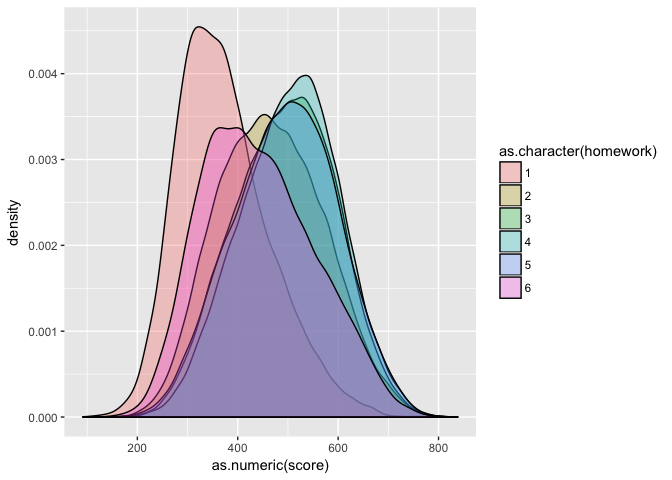

```
##                 Df    Sum Sq  Mean Sq F value Pr(>F)
## homework         1 4.157e+07 41573828    3825 <2e-16 ***
## Residuals   258582 2.811e+09    10870
## ---
## Signif. codes:  0 '***' 0.001 '**' 0.01 '*' 0.05 '.' 0.1 ' ' 1
```

معلمانی که در کلاس های آمادگی شرکت میکنند و در مجموع فعالیت بیشتری برای آمادگی خود انجام میدهند دانش آموزان موفق تری دارند.

طبق سوالات مربوط به کلاس ها، سمینارها و .. امتیازی برای معلمان از نظر آمادگی محاسبه شد و طبق آن جامعه را دو دسته کردیم. طبق تست فرض، فرض بیشتر بودن میانگین نمرات معلمان آماده تر فرض ۰ را رد کرد

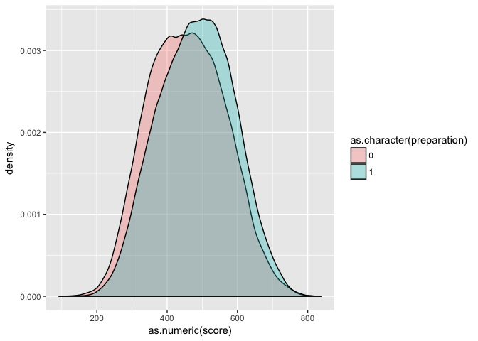

```
##
##  Welch Two Sample t-test
##
## data:  score by preparation
## t = -48.407, df = 84731, p-value < 2.2e-16
## alternative hypothesis: true difference in means is less than 0
## 95 percent confidence interval:
##       -Inf -24.65153
## sample estimates:
## mean in group 0 mean in group 1
##        456.9664        482.4850
```